# Human Activity Recognition

Jesse Schevers

Saturday, July 25, 2015

## Introduction

This is the report for the **Coursera** course *Practical Machine Learning*. Our goal is to predict *how well* a weightlifting exercise is performed. We will use data from accelerometers on the belt, forearm, arm, and dumbbel of 6 participants. They were asked to perform barbell lifts correctly and incorrectly in 5 different ways.

More information is available on the [HAR](http://groupware.les.inf.puc-rio.br/har) website.

## The Data

The Weight Lifting Exercise Dataset can be downloaded here:

- [training dataset](https://d396qusza40orc.cloudfront.net/predmachlearn/pml-training.csv)
- [test dataset](https://d396qusza40orc.cloudfront.net/predmachlearn/pml-testing.csv)

There are five *Classes* quantifying what *how well* means:

- Class **A**: exactly according to the specification,
- Class **B**: throwing the elbows to the front,
- Class **C**: lifting the dumbbell only halfway,
- Class **D**: lowering the dumbbell only halfway,
- Class **E**: throwing the hips to the front

I will split the (downloaded) training dataset into a trainingset and a validationset. The trainingset will be used to build the model(s), the validationset for cross-validation and the (downloaded) test dataset for the assignment submission.  
We can’t use all the variables. There first few variables are about the experiment set-up. The variables with Na’s (or NULL’s) have only few or no values. In the test dataset, these variables have all missing values. So they will be removed.

The variable we are trying to predict is **classe**. The covariates are:

| roll_belt | roll_arm | roll_dumbbell | roll_forearm |
| --- | --- | --- | --- |
| pitch_belt | pitch_arm | pitch_dumbbell | pitch_forearm |
| yaw_belt | yaw_arm | yaw_dumbbell | yaw_forearm |
| total_accel_belt | total_accel_arm | total_accel_dumbbell | total_accel_forearm |
| gyros_belt_x | gyros_arm_x | gyros_dumbbell_x | gyros_forearm_x |
| gyros_belt_y | gyros_arm_y | gyros_dumbbell_y | gyros_forearm_y |
| gyros_belt_z | gyros_arm_z | gyros_dumbbell_z | gyros_forearm_z |
| accel_belt_x | accel_arm_x | accel_dumbbell_x | accel_forearm_x |
| accel_belt_y | accel_arm_y | accel_dumbbell_y | accel_forearm_y |
| accel_belt_z | accel_arm_z | accel_dumbbell_z | accel_forearm_z |
| magnet_belt_x | magnet_arm_x | magnet_dumbbell_x | magnet_forearm_x |
| magnet_belt_y | magnet_arm_y | magnet_dumbbell_y | magnet_forearm_y |
| magnet_belt_z | magnet_arm_z | magnet_dumbbell_z | magnet_forearm_z |

## The Model

Since this is a classification problem I will use tree-based-models. A single tree can easily be interpreted, but the covariates itself are not very interpretable (a lot of sensor-data), so interpretably is not so much of an issue here, therefore a random forest is much more interesting. (of course I did build a single tree (ctree), but I was not a very good predictor)  
First I tried to build a random forest based on conditional inference trees (cforest), but my computer ran out of memory. So a *cforest* is not an option (for me). So I will go for a **random forest**.

## Results Random Forest

The trainingset will be used for building the model. I will save the resulting “train”-object on disk and load it when I need it.

```r
#fit_forest= train(y=trainset$classe , x=trainset[,!names(trainset)=="classe"]
#                ,method="rf")
#saveRDS(fit_forest, file="fit_forest.rds")
fit_forest=readRDS("fit_forest.rds")
valset$pred_rf= predict(fit_forest,newdata=valset[,fields])
cM=confusionMatrix(data=valset$pred_rf,reference=valset$classe)
```

I used the validationset for cross-validation. Let’s take a look at the confusionmatrix for the validationset:

```
## Confusion Matrix and Statistics
##
##           Reference
## Prediction    A    B    C    D    E
##          A 1116    7    0    0    0
##          B    0  751   10    0    0
##          C    0    1  673   14    0
##          D    0    0    1  629    1
##          E    0    0    0    0  720
##
## Overall Statistics
##
##                Accuracy : 0.9913
##                  95% CI : (0.9879, 0.994)
##     No Information Rate : 0.2845
##     P-Value [Acc > NIR] : < 2.2e-16
##
##                   Kappa : 0.989
##  Mcnemar's Test P-Value : NA
##
## Statistics by Class:
##
##                      Class: A Class: B Class: C Class: D Class: E
## Sensitivity            1.0000   0.9895   0.9839   0.9782   0.9986
## Specificity            0.9975   0.9968   0.9954   0.9994   1.0000
## Pos Pred Value         0.9938   0.9869   0.9782   0.9968   1.0000
## Neg Pred Value         1.0000   0.9975   0.9966   0.9957   0.9997
## Prevalence             0.2845   0.1935   0.1744   0.1639   0.1838
## Detection Rate         0.2845   0.1914   0.1716   0.1603   0.1835
## Detection Prevalence   0.2863   0.1940   0.1754   0.1608   0.1835
## Balanced Accuracy      0.9988   0.9931   0.9896   0.9888   0.9993
```

The *Accuracy* on the validationset is 0.991, so the *out of sample error rate* is 1-0.991= 0.009. Since the validationset is not used for building the model, this is a good estimate for the *out of sample error*.

As a bonus, I want to see how the most important covariates relate to *classe*. Let’s take a look at the (top 10) variable importance:

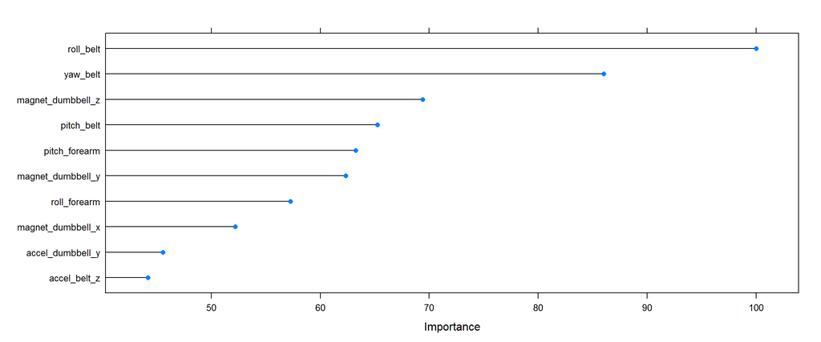

*roll_belt* and *yaw_belt* are on top. Let’s see how they relate to *classe*:

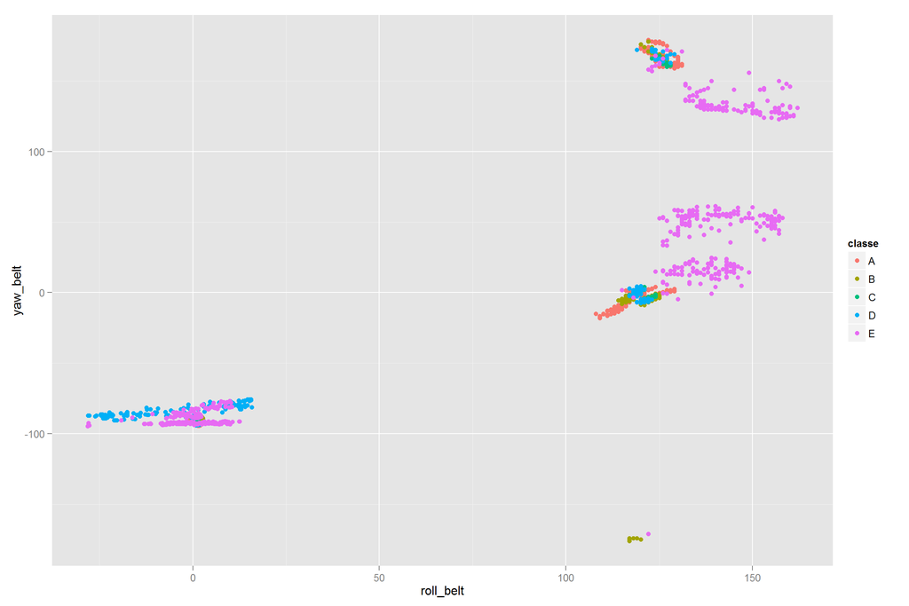